# Types of Distributions

## Gaussian (Normal) distribution

Normal or Gaussian distribution of continuous random variables is defined mathematically as

$$y=\frac{e^{-(X-μ)^2/(2σ^2)}} {σ \sqrt {2π}}$$

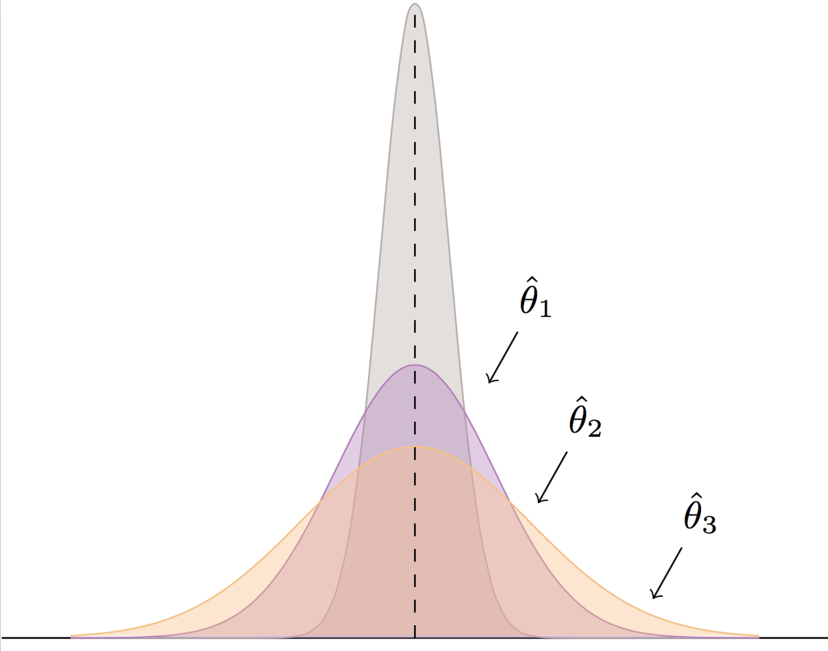

where

μ is the mean, σ is the standard deviation, $σ^2$ is the variance, π = 3.14(approx), e = 2.718(approx)

### Examples

Heights of people, test scores etc. Normal distribution has same mean, median and mode.

### Exercise

Let's get started with a Gaussian distribution and plot it. Notice the bell shaped curve.

- Compute the probability of x=0 using norm.pdf function and assign it to the variable prob. Use Shift+tab to look up the function input arguments.

```
0.3989422804014327
```

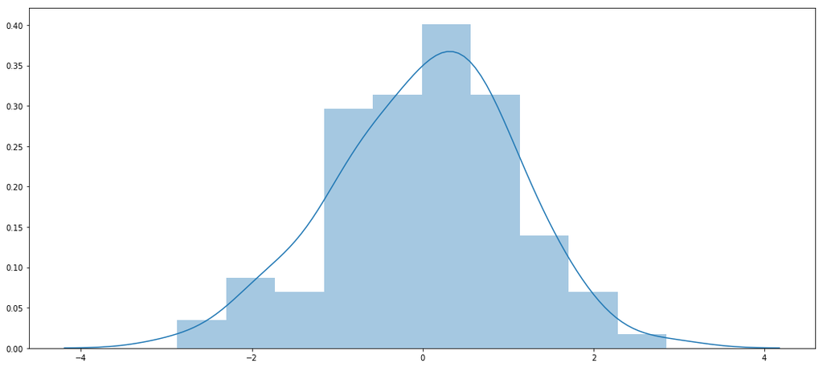

```python
from scipy.stats import norm
import numpy as np
import seaborn as sns
import matplotlib.pyplot as plt

ax = plt.subplots(figsize=(18, 8))
x = np.random.normal(scale=1.0, size=100)
sns.distplot(x)
prob = norm.pdf(0, scale=1, loc=0)
print(prob)
```

### Solution

```
x = np.random.normal(scale=1.0, size=100)
sns.distplot(x)
prob = norm.pdf(0, scale=1, loc=0)
print(prob)
```

## Exponential distribution

where λ > 0 is the average number of occurences in a unit of time.

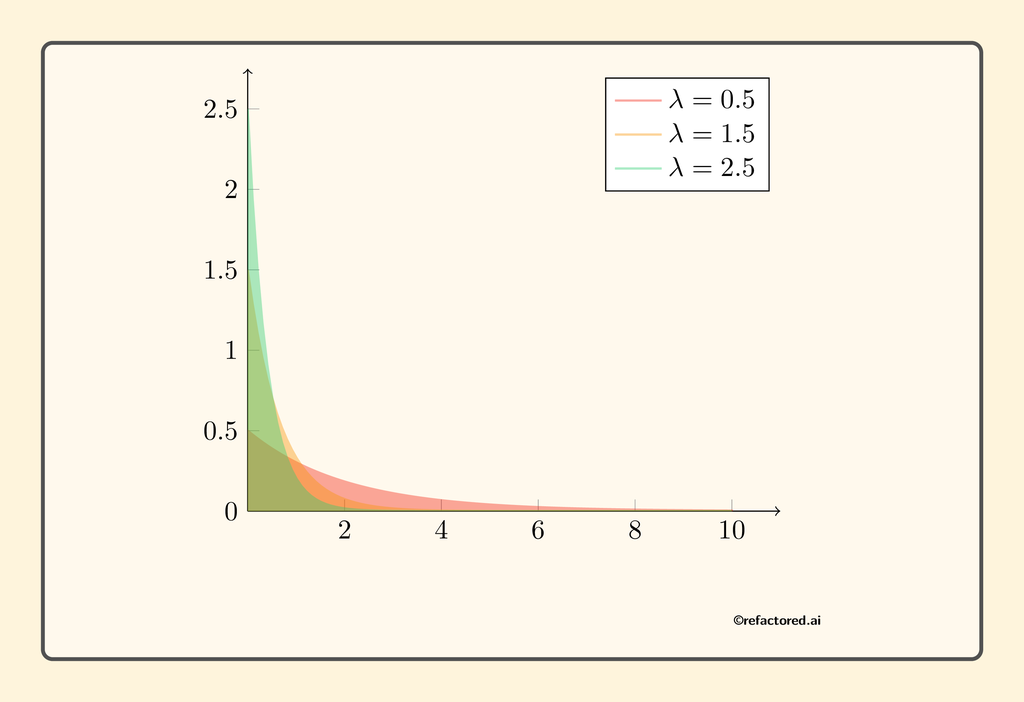

### Exercise

Let us now plot a Exponential distribution.

- Compute the mean and variance of the Exponential Distribution and assign it to mu, var.

```
0.5 0.25
```

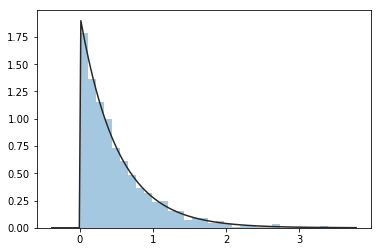

```python
import matplotlib.pyplot as plt
from scipy import stats
%matplotlib inline
from scipy.stats import expon
import numpy as np
import seaborn as sns

lambdax = 2

x = expon.rvs(0, 1/lambdax , 1000)

loc, scale = expon.fit(x, floc=0)

sns.distplot(x, kde=False, fit=stats.expon);
mu = 1/lambdax
var = 1/(lambdax**2)
print(mu, var)
```

### Solution

```
mu = 1/lambdax
var = 1/(lambdax**2)
print(mu, var)
```

## Gamma distribution

Gamma distribution is a continuous probability distribution. The Probability Density Function of Gamma distribution is mathematically defined as

$$f(x,α,β) = \frac {β^α x^{α-1}{e^{-βx}}} {Γ(α)} $$

where Γ(α) is a complete Gamma function.

### Examples

Typical events modeled using gamma distribution are accumulated rainfall, aggregate loan default, load on server etc.

### Exercise

Let's plot a Gamma distribution.

- Compute the mean and variance of the Gamma Distribution and assign it to mu, var.

```
2.0 2.0
```

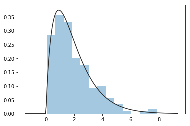

```python
import matplotlib.pyplot as plt
from scipy import stats
%matplotlib inline
import numpy as np
import seaborn as sns

alpha = 2
beta = 1
x = np.random.gamma(alpha, beta, size=200)
g = sns.distplot(x, kde=False, fit=stats.gamma);
# Modify the code below
mu = alpha/beta
var = alpha/(beta*beta)
print(mu, var)
```

### Solution

```
mu = alpha/beta
var = alpha/(beta*beta)
print(mu, var)
```

## Bernoulli Distribution

Bernoulli distribution is the probability distribution of a random variable that takes a boolean value such as a 1 or 0. The Probability Mass Function of Bernoulli distribution is mathematically defined as:

For a possible outcome k,

$$f(k,p) = {p^k}({{1-p})^{(1-k)}} $$

where p is the probability of outcome 1 and 1-p is the probability of outcome 0.

### Examples

Result of a coin toss, if patient has disease or not, any experiment with outcome of success or failure.

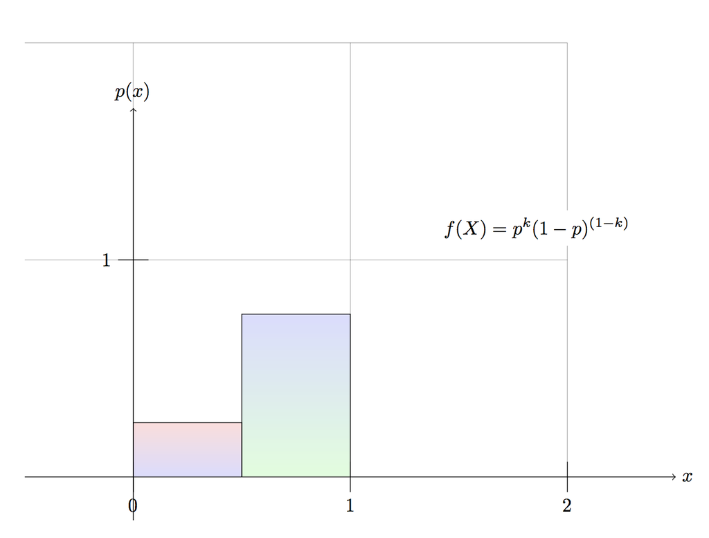

Let us now plot a Bernoulli distribution

### Exercise

- Increase number of samples to 1000 and use bernoulli.stats() function to determine the mean of the distribution.
- Assign it to variable, mu and print it out.

```
0.3
```

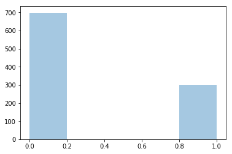

```python
%matplotlib inline
from scipy.stats import bernoulli
import numpy as np
import seaborn as sns

p = 0.3
x = bernoulli.rvs(p, size=1000)
sns.distplot(x, kde=False);
mu = bernoulli.stats(p, moments='m')
print(mu)
```

### Solution

```
mu = bernoulli.stats(p, moments='m')
print(mu)
```

## Binomial Distribution

The number of successes, $x$ in a fixed number of $n$ independent Bernoulli trials with probability of success $p$ or $\theta$, follows a binomial distribution. $n$ and $p$ are always fixed in a binomial distribution.

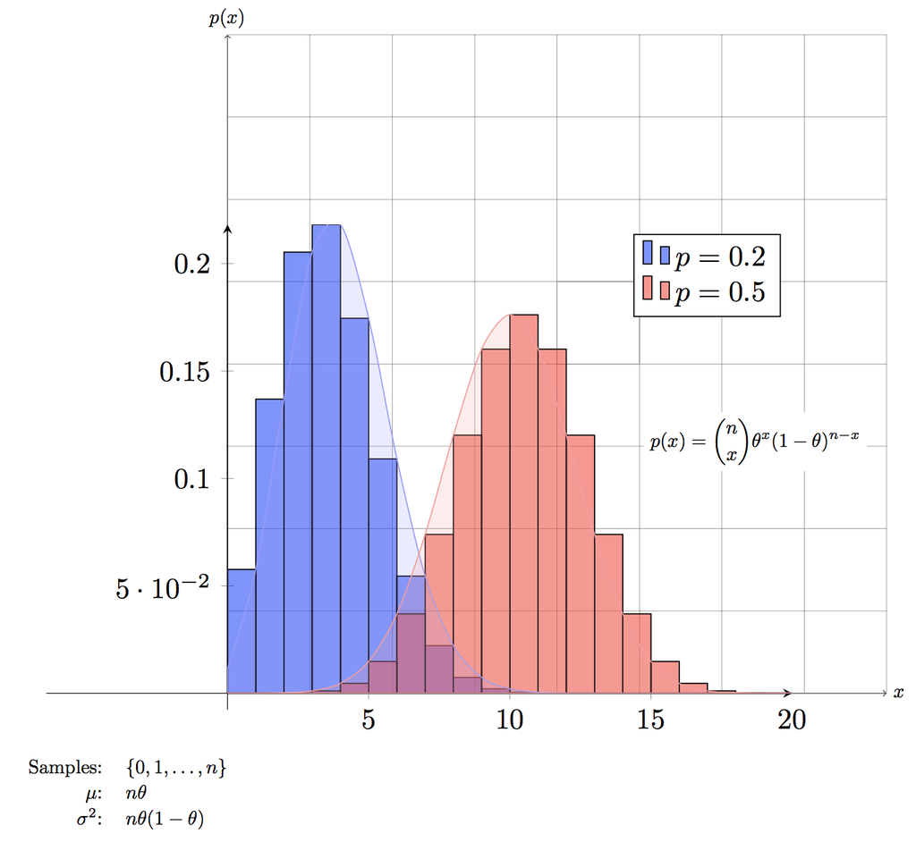

### Examples

Number of heads after tossing a coin 100 times. Number of defective bulbs after inspecting 1000 bulbs.

### Exercise

Let us generate numbers that conform to a binomial distribution. Given N = 40, p=0.5 and the numbers distributed according to the binomial pmf, compute the mean and variance and assign it to variables, mu and var.

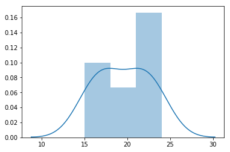

```python
%matplotlib inline

import numpy as np
import seaborn as sns

N = 40
p = 0.5
binomial_x = np.random.binomial(N, p, 10)
sns.distplot(binomial_x)

# Compute mean and variance
```

### Solution

```
mu = N*p
var = N*p*(1-p)
print(mu, var)
```

## Poisson Distribution

The probability distribution of a Poisson random variable X is the number of events occurring in a given time interval.

Poisson distribution of discrete random variables is defined mathematically as

$$P(X)=e^{-μ}\frac{μ^x} {x!}$$

[figure not shown]

where

X = 0, 1, 2, …

e = 2.71828

μ = mean number of events in the given time interval

### Examples

Number of cars crossing a traffic signal in 30 minutes. Number of phone calls at a service desk in 5 minutes. Number of patients coming into a hospital every hour.

### Exercise

Let us now plot a poisson distribution.

- Increase number of samples to 1000 and use np.mean function to determine the mean of the distribution.
- Assign it to variable, mu and print it out.

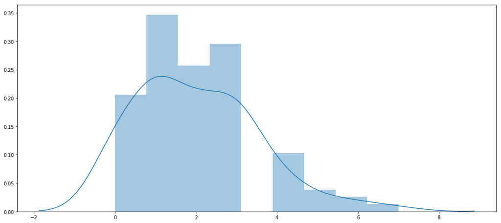

```python
ax = plt.subplots(figsize=(18, 8))
x = np.random.poisson(lam=2, size=100)
sns.distplot(x)
```

### Solution

```
ax = plt.subplots(figsize=(18, 8))
x = np.random.poisson(lam=2, size=1000)
sns.distplot(x)

mu = np.mean(x)
print(mu)
```